# NCBN Salt Marsh Vegetation Monitoring Protocol Review

###### *Community Composition*

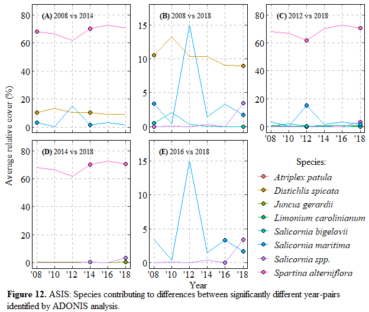

At COLO, the permutational analysis of variance (ADONIS) found a significant difference in community composition between years (*R*2 = 0.21, *p* < 0.001). An examination of the pairwise comparisons between years at COLO found significant differences between 10 year-pairs including 2008 vs. 2010, 2008 vs. 2012, 2008 vs. 2014, 2008 vs. 2016, 2010 vs. 2012, 2010 vs. 2014, 2010 vs. 2016, 2012 vs. 2014, 2012 vs. 2016, and 2014 vs. 2016. (Figure 13). Only the species with the top 5 greatest changes in cover that contributed to the differences between these 10 year-pairs at COLO are shown in Figure 13. Additional species with significant differences in cover between at least 1 year pair at COLO include *Amaranthus cannabinus*, *Carex hyalinolepsis*, *Carex lurida*, *Eleocharis parvula*, *Juncus effusus*, *Juncus gerardii*, *Juncus roemarianus*, *Juncus tenuis*, *Leersia oryzoides*, *Lythrum lineare*, *Mikania scandens*, *Phragmites australis*, *Pluchea odorata*, *Polygonum punctatum*, *Pontedaria cordata*, *Schoenoplectus americanus*, *Schoenoplectus pungens var. pungens*, *Schoenoplectus tabernaemontani*, *Typha spp.*, *Typha angustifolia*, and *Zizaniopsis miliacea*.

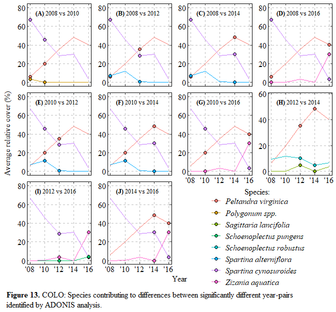

At FIIS, the permutational analysis of variance (ADONIS) found a significant difference in community composition between years (*R*2 = 0.02, *p* < 0.001). An examination of the pairwise comparisons between years at FIIS found significant differences between 2009 vs. 2011, 2009 vs. 2013, 2009 vs. 2015, 2011 vs. 2013, 2011 vs. 2017, 2013 vs. 2015, 2013 vs. 2017, and 2015 vs. 2017 (Figure 14). Only the species with the top 5 greatest changes in cover that contributed to the differences between these 8 year-pairs at FIIS are shown in Figure 14. Additional species with significant differences in cover between at least 1 year pair at FIIS include *Atriplex patula*, *Baccharis halimifolia*, *Hibiscus spp.*, *Hibiscus moscheutos*, *Kosteletzkya virginica*, *Limonium carolinianum*, *Salicornia bigelovii*, *Schoenoplectus pungens*, *Schoenoplectus robustus*, *Suaeda maritima*, and *Symphyotrichum tenuifolium*.

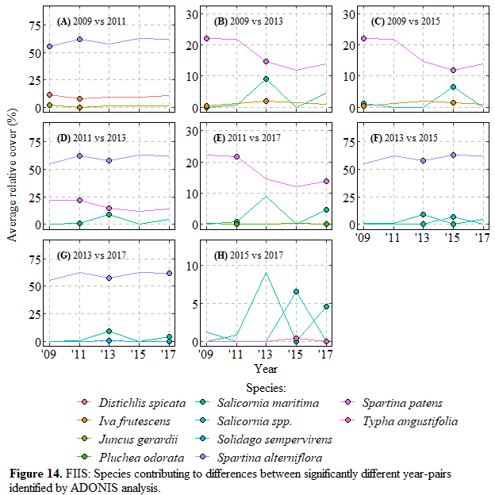

At GEWA, the permutational analysis of variance (ADONIS) found a significant difference in community composition between years (*R*2 = 0.18, *p* < 0.001). An examination of the pairwise comparisons between years at GEWA found significant differences between 2008 vs. 2010 and 2010 vs. 2012 (Figure 15). The species with significant differences in cover that contributed to the differences between these year-pairs at GEWA are shown in Figure 15.

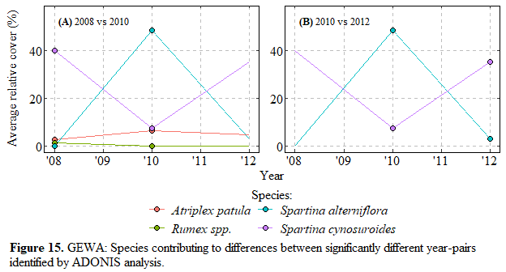